# P1_Morris_Taylor

Taylor B. Morris

January 19, 2017

# Question 1

Classification distinguishes, or classifies, data by discrete categorical values whereas regression predicts a continuous value given input. Both procedures accept continuous and discrete features.

# Q2

```r
adultHtml<-"http://archive.ics.uci.edu/ml/machine-learning-databases/adult/adult.data"
adult <- read.table(adultHtml, sep=',',header=F, na.strings = " ?")
names(adult) <- c("age","workclass","fnlwgt","education","education-num","marital-status",
                  "occupation","relationship","race","sex", "capital-gain",
                  "capital-loss","hours-per-week","native-country",">50k <=50k")
```

## Q2a

Information on each variable:

- **age**: Age is the integer age of this adult as reported in the 1994 census.
- **workclass**: Workclass describes what type of employment this adult has as of the 1994 census; the value is reported as a nominal descriptor.
- **fnlwgt**: The final sampling weight is described by fnlwgt; fnlwgt is a continuous value.
- **education**: The level of education is described using a ordinal representation such as Bachelors or Some-college.
- **education-num**: The level of education as described using a continuous value (an integer) to represent the education level.
- **marital-status**: Marital-status describes the marital status of the adult as of the 1994 census using a nominal representation.
- **occupation**: The occupation of the adult refers to their field of employment; for example, Tech-support or Craft-repair are sample nominal representations used.
- **relationship**: Relationship represents the relationship between this adult and another adult from the other adult’s perspective using a nominal representation.
- **race**: The race attribute describes which racial group the individual identifies as using a nominal descriptor.
- **sex**: Sex is a binary attribute differentiating male and female adults.
- **capital-gain**: Capital-gain describes the profits the individual has made from investments and is described using an integer dollar amount.
- **capital-loss**: Capital-loss describes any losses due to underselling investments as a integer dollar amount.
- **hours-per-week**: Hours-per-week is an integer value representing the number of hours reported to work a week by this individual.
- **native-country**: The native-country attribute is a nominal attribute describing the individual’s native - or home - country.

## Q2b

Information on missing data:

```r
n <- nrow(adult)
sapply(adult, function(x) sum(is.na(x))/n)
```

```
##            age      workclass         fnlwgt      education  education-num
##     0.00000000     0.05638647     0.00000000     0.00000000     0.00000000
## marital-status     occupation   relationship           race            sex
##     0.00000000     0.05660146     0.00000000     0.00000000     0.00000000
##   capital-gain   capital-loss hours-per-week native-country     >50k <=50k
##     0.00000000     0.00000000     0.00000000     0.01790486     0.00000000
```

## Q2c

Information on variable types:

- **Numeric**: age, fnlwgt, education-num, capital-gain, capital-loss, hours-per-week
- **Categorical**: workclass, eduction, marital-status, occupation, relationship, race, sex, native-country

## Q2d

Numeric variable exploration for age and education-num

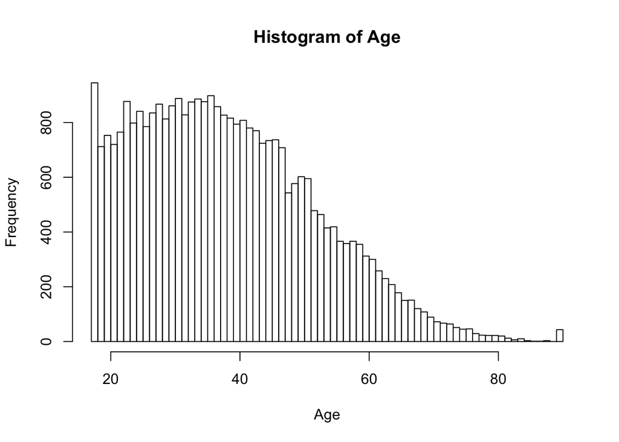

```r
age.distinct <- length(unique(adult$age))
if ( age.distinct < 50 ) {
  hist(adult$age, breaks=unique(adult$age),xlab="Age",
     main="Histogram of Age")
} else {
  hist(adult$age, breaks=99,xlab="Age",
     main="Histogram of Age")
}
```

Total number of distinct values for age: 73

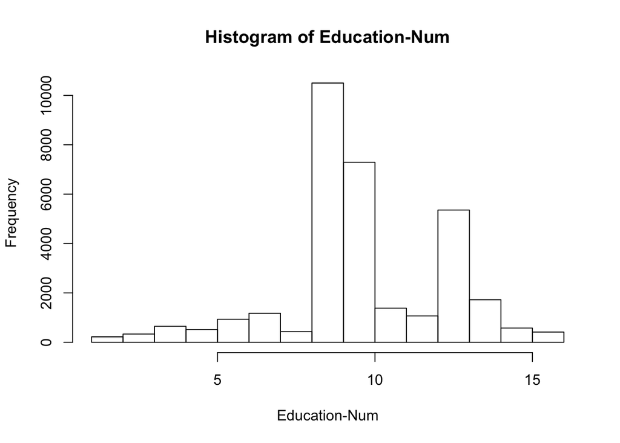

```r
educationnum.distinct <- length(unique(adult$"education-num"))
if ( educationnum.distinct < 50 ) {
  hist(adult$"education-num", breaks=unique(adult$"education-num"),xlab="Education-Num",
     main="Histogram of Education-Num")
} else {
  hist(adult$"education-num", breaks=99,xlab="Education-Num",
     main="Histogram of Education-Num")
}
```

Total number of distinct values for education-num: 16